# Custom thank you page message in Qualtrics

### Setting a custom thank you page

- I’ll be offering students in another class some extra credit for completing your survey, but in order to track their participation, I need your survey to redirect them to a separate survey where they can enter their UID number.
- This isn’t overly complicated, but just to make sure everyone gets the same stuff, I’m including these instructions.

### Setting up a custom thank you page: Step 1

Step 1. Navigate to your survey in the survey builder and click the block at the bottom of your survey.

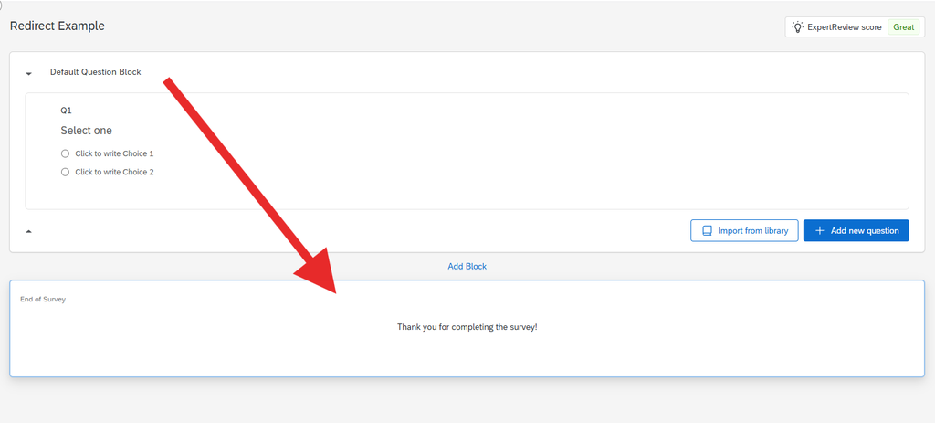

### Setting up a custom thank you page: Step 2

Step 2. Click the “end of survey” section, and you should see some options appear in the left panel

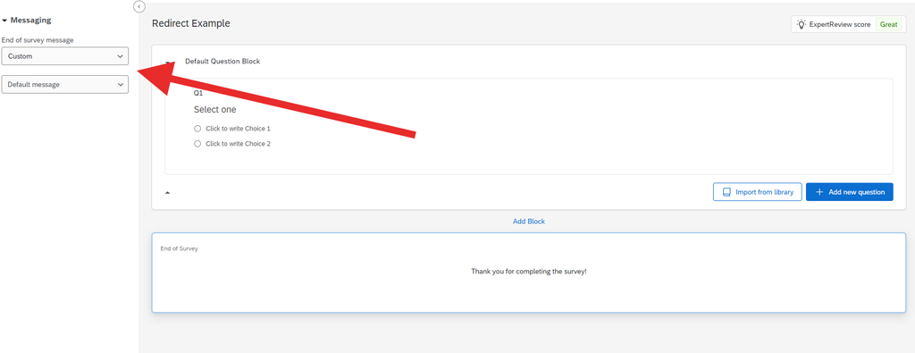

### Setting up a custom thank you page: Step 3

Step 3. Use the dropdown menu to select “Custom” for the end of survey message.

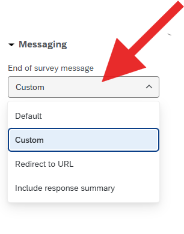

### Setting up a custom thank you page: Step 4

Step 4. Select the lower menu and go to “My Library” > “New message”

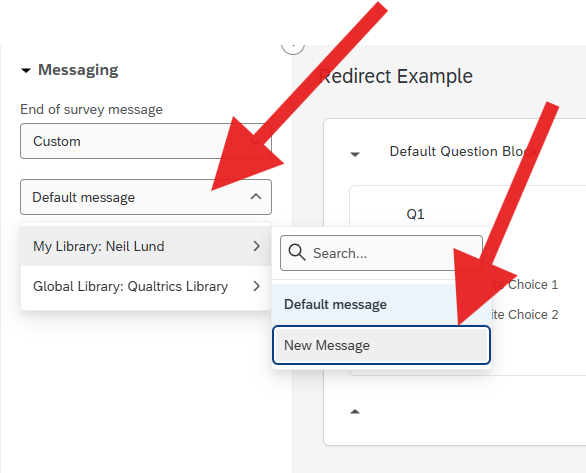

### Setting up a custom thank you page: Step 5

Step 5. Enter a name in the “Description” field, then hit the “source” icon to bring up the source code editor.

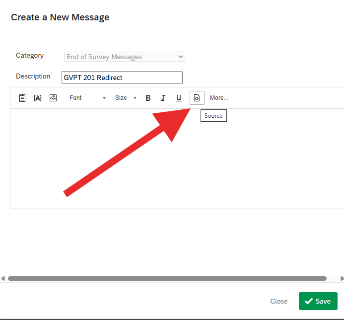

### Setting up a custom thank you page: Step 6

Step 6. Make sure the source icon is highlighted, then you can copy the code from below into the editor window exactly as written.

```html
<p>Thank you for completing this survey! Your response has been recorded.</p>
<p><b>If you are a student in GVPT201, please
<a href="https://umdsurvey.umd.edu/jfe/form/SV_bwMeEjXJ7sAnWe2?origin=umd">click here</a>
and enter your UID so you can receive credit for completing the survey.</b></p>
```

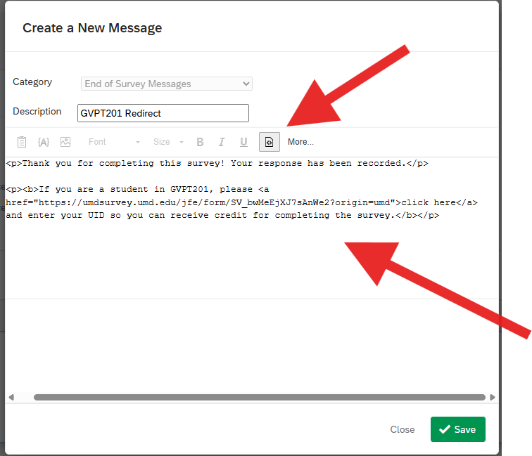

### Setting up a custom thank you page: Step 7

Step 7. Hit save

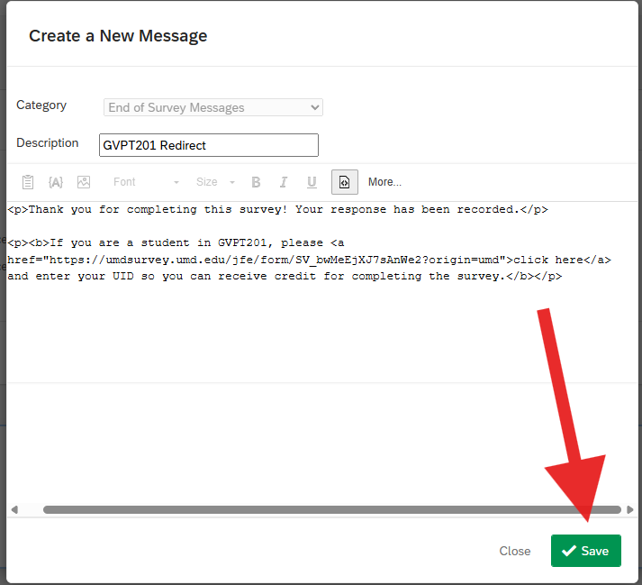

### Setting up a custom thank you page: Step 8

Step 8. Make sure the survey block should looks something like this:

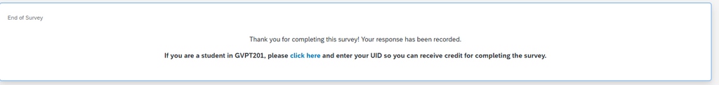

### Setting up a custom thank you page: Step 9

Step 9. Hit the “Publish” button at the top right, this will update your survey with the new end of survey message

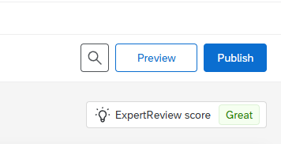

### Setting up a custom thank you page: Step 10

Step 10 Verify that the link works. Clicking the blue link text should send you to this page:

[figure not shown]

### Setting up a custom thank you page

That’s it! Please send me an email if you have any questions.